# Assignment 2

Richard Choi

20 August 2021

Using the data from week 2 of January 2016, construct a model that predicts the amount of a tip. Evaluate the mean squared error of this model on the data from week 4 of January 2016. Write a report that describes how you constructed the model and how accurate it is.

Submit the rmd and the knitted pdf or html.

Notes:

1. The data sets are fairly large. Each one has a couple of million records. You should still be able to run `regsubsets` and `lm` fairly quickly.
2. As the data dictionary indicates, tip information is not available for all trips
3. These data have not been cleaned; they are as they came from the data provider.
4. You will want to recode variables such as pickup and dropoff time and location into categories: they will not have linear relationships with tip amount. Some graphical exploration is likely to be helpful in addition to thinking about the problem. If you have problems drawing graphs because of the size of the data, taking a random subsample of, say, 10% of it can be useful.
5. The `total_amount` variable is the total amount paid. It includes the tip, and so can’t be used to predict the tip.

```r
library(tidyverse)
library(lubridate)
library(dplyr)
week2.df = read_csv("week2.csv")
week4.df = read_csv("week4.csv")
# Inspecting data

summary(week2.df)
```

```
##     VendorID     tpep_pickup_datetime          tpep_dropoff_datetime
##  Min.   :1.000   Min.   :2016-01-08 00:00:00   Min.   :2016-01-08 00:01:23
##  1st Qu.:1.000   1st Qu.:2016-01-09 18:02:05   1st Qu.:2016-01-09 18:16:14
##  Median :2.000   Median :2016-01-11 15:19:10   Median :2016-01-11 15:33:52
##  Mean   :1.532   Mean   :2016-01-11 14:11:04   Mean   :2016-01-11 14:25:25
##  3rd Qu.:2.000   3rd Qu.:2016-01-13 11:35:15   3rd Qu.:2016-01-13 11:50:25
##  Max.   :2.000   Max.   :2016-01-14 23:59:59   Max.   :2016-01-15 23:39:18
##  passenger_count trip_distance     pickup_longitude  pickup_latitude
##  Min.   :0.000   Min.   :  0.000   Min.   :-121.93   Min.   : 0.00
##  1st Qu.:1.000   1st Qu.:  1.000   1st Qu.: -73.99   1st Qu.:40.74
##  Median :1.000   Median :  1.630   Median : -73.98   Median :40.75
##  Mean   :1.659   Mean   :  2.809   Mean   : -72.84   Mean   :40.13
##  3rd Qu.:2.000   3rd Qu.:  3.000   3rd Qu.: -73.97   3rd Qu.:40.77
##  Max.   :9.000   Max.   :502.200   Max.   :   0.00   Max.   :46.31
##    RatecodeID     store_and_fwd_flag dropoff_longitude dropoff_latitude
##  Min.   : 1.000   Length:2651287     Min.   :-121.93   Min.   : 0.00
##  1st Qu.: 1.000   Class :character   1st Qu.: -73.99   1st Qu.:40.74
##  Median : 1.000   Mode  :character   Median : -73.98   Median :40.75
##  Mean   : 1.036                      Mean   : -72.91   Mean   :40.17
##  3rd Qu.: 1.000                      3rd Qu.: -73.96   3rd Qu.:40.77
##  Max.   :99.000                      Max.   :   0.00   Max.   :52.75
##   payment_type    fare_amount          extra             mta_tax
##  Min.   :1.000   Min.   :-957.60   Min.   :-35.6400   Min.   :-0.5000
##  1st Qu.:1.000   1st Qu.:   6.50   1st Qu.:  0.0000   1st Qu.: 0.5000
##  Median :1.000   Median :   9.00   Median :  0.0000   Median : 0.5000
##  Mean   :1.337   Mean   :  12.06   Mean   :  0.3235   Mean   : 0.4978
##  3rd Qu.:2.000   3rd Qu.:  13.50   3rd Qu.:  0.5000   3rd Qu.: 0.5000
##  Max.   :4.000   Max.   :3039.00   Max.   :  4.1000   Max.   :36.4400
##    tip_amount        tolls_amount      improvement_surcharge  total_amount
##  Min.   :-220.800   Min.   :-12.5000   Min.   :-0.3000       Min.   :-958.40
##  1st Qu.:   0.000   1st Qu.:  0.0000   1st Qu.: 0.3000       1st Qu.:   8.30
##  Median :   1.320   Median :  0.0000   Median : 0.3000       Median :  11.30
##  Mean   :   1.728   Mean   :  0.2746   Mean   : 0.2998       Mean   :  15.18
##  3rd Qu.:   2.260   3rd Qu.:  0.0000   3rd Qu.: 0.3000       3rd Qu.:  16.56
##  Max.   : 900.000   Max.   :811.0000   Max.   : 0.3000       Max.   :3045.34
```

```r
sum(week2.df$fare_amount < 0)
```

```
## [1] 930
```

```r
unique(week2.df$RatecodeID)
```

```
## [1]  1  5  2  4  3 99  6
```

```r
unique(week2.df$payment_type)
```

```
## [1] 1 2 4 3
```

```r
unique(week2.df$store_and_fwd_flag)
```

```
## [1] "N" "Y"
```

```r
sum(week2.df$extra < 0)
```

```
## [1] 448
```

```r
any(is.na(week2.df))
```

```
## [1] FALSE
```

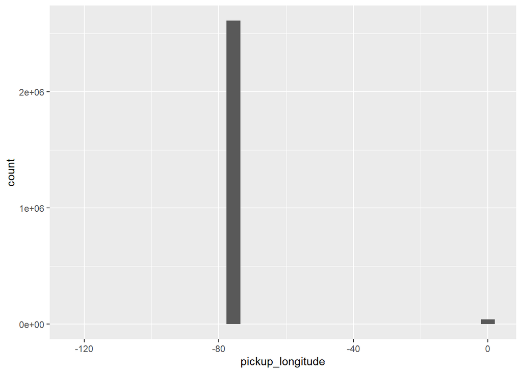

```r
week2.df %>%
  ggplot(aes(x=pickup_longitude)) + geom_histogram()
```

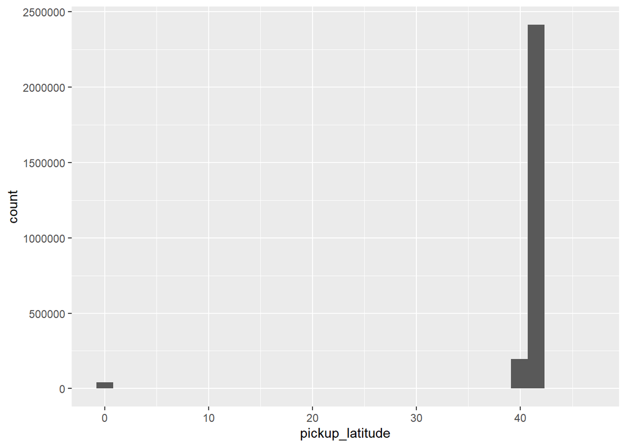

```r
week2.df %>%
  ggplot(aes(x=pickup_latitude)) + geom_histogram()
```